# Quiz 13

## Instructions

> Write your name at the top right. You are to work on this quiz alone without any help from any other resource **except for a single $8.5 \times 11$ inch page of handwritten notes**.  
> This quiz will be ungraded but must be handed in for attendance.

## Problems:

In each of the below we have a confidence interval for a transformation of the response.

### Problem 1:

Here we see the confidence interval for the Box-Cox transformation. In this case, can we reject the null hypothesis (no transformation) at $5\%$ significance?

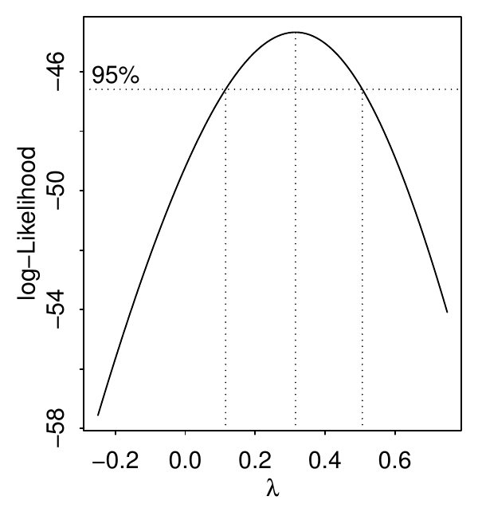

#### Solution:

For the Box-Cox transformation, the null hypothesis is that the transformation is a power of one. In this case, we can reject the null as this is excluded from our confidence interval.

### Problem 2:

Here we see the confidence interval for the Box-Cox transformation. In this case, can we reject the null hypothesis (no transformation) at $5\%$ significance?

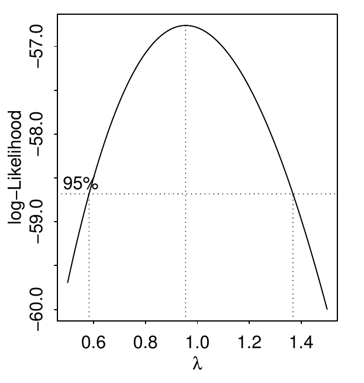

#### Solution:

We note, in this case a power of one is a plausible value according to the confidence interval, and thus we cannot reject the null.

### Problem 3:

Here we see the confidence interval for the shifted log transformation. Does this plot indicate that a regular log transformation (no shift) is reasonable? If not, what is a reasonable value for the shift?

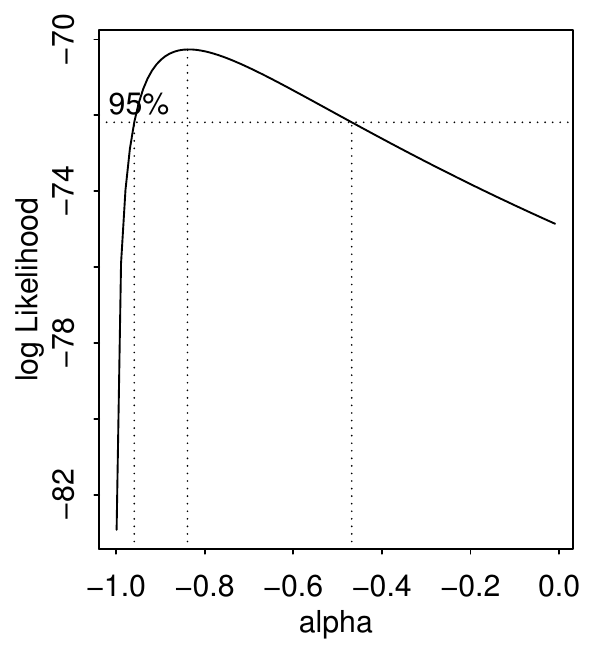

#### Solution:

In this case, zero is not included in the confidence interval suggesting that the log transformation in of itself is not appropriate. However, a shift of around -0.8 would be a reasonable choice in this context.